# Biostat 200C Homework 2

Due Apr 25 @ 11:59PM

Published

July 24, 2025

To submit homework, please upload both Rmd and html files to Bruinlearn by the deadline.

## 1 Q1. CFR of COVID-19 (90pts)

Of primary interest to public is the risk of dying from COVID-19. A commonly used measure is case fatality rate/ratio/risk (CFR), which is defined as
$$\frac{\text{number of deaths from disease}}{\text{number of diagnosed cases of disease}}.$$
Apparently CFR is not a fixed constant; it changes with time, location, and other factors. Also CFR is different from the infection fatality rate (IFR), the probability that someone infected with COVID-19 dies from it.

In this exercise, we use logistic regression to study how US county-level CFR changes according to demographic information and some health-, education-, and economy-indicators.

### 1.1 Data sources

- `04-04-2020.csv.gz`: The data on COVID-19 confirmed cases and deaths on 2020-04-04 is retrieved from the [Johns Hopkins COVID-19 data repository](https://github.com/CSSEGISandData/COVID-19). It was downloaded from this [link](https://github.com/CSSEGISandData/COVID-19) (commit 0174f38). This repository has been archived by the owner on Mar 10, 2023. It is now read-only. You can download data from box: https://ucla.box.com/s/brb3vz4nwoq8pjkcutxncymqw583d39l
- `us-county-health-rankings-2020.csv.gz`: The 2020 County Health Ranking Data was released by [County Health Rankings](https://www.countyhealthrankings.org). The data was downloaded from the [Kaggle Uncover COVID-19 Challenge](https://www.kaggle.com/roche-data-science-coalition/uncover) (version 1). You can download data from box: https://ucla.box.com/s/brb3vz4nwoq8pjkcutxncymqw583d39l

### 1.2 Sample code for data preparation

Load the `tidyverse` package for data manipulation and visualization.

```r
# tidyverse of data manipulation and visualization
library(tidyverse)
library(dplyr)
library(car)
library(tibble)
library(glmnet)
library(MASS)
```

Read in the data of COVID-19 cases reported on 2020-04-04.

```r
county_count <- read_csv("~/Downloads/04-04-2020.csv.gz") %>%
  # cast fips into dbl for use as a key for joining tables
  mutate(FIPS = as.numeric(FIPS)) %>%
  filter(Country_Region == "US") %>%
  print(width = Inf)
```

```
# A tibble: 2,421 × 12
    FIPS Admin2    Province_State Country_Region Last_Update           Lat
   <dbl> <chr>     <chr>          <chr>          <dttm>              <dbl>
 1 45001 Abbeville South Carolina US             2020-04-04 23:34:21  34.2
 2 22001 Acadia    Louisiana      US             2020-04-04 23:34:21  30.3
 3 51001 Accomack  Virginia       US             2020-04-04 23:34:21  37.8
 4 16001 Ada       Idaho          US             2020-04-04 23:34:21  43.5
 5 19001 Adair     Iowa           US             2020-04-04 23:34:21  41.3
 6 21001 Adair     Kentucky       US             2020-04-04 23:34:21  37.1
 7 29001 Adair     Missouri       US             2020-04-04 23:34:21  40.2
 8 40001 Adair     Oklahoma       US             2020-04-04 23:34:21  35.9
 9  8001 Adams     Colorado       US             2020-04-04 23:34:21  39.9
10 16003 Adams     Idaho          US             2020-04-04 23:34:21  44.9
    Long_ Confirmed Deaths Recovered Active Combined_Key
    <dbl>     <dbl>  <dbl>     <dbl>  <dbl> <chr>
 1  -82.5         6      0         0      0 Abbeville, South Carolina, US
 2  -92.4        65      2         0      0 Acadia, Louisiana, US
 3  -75.6         8      0         0      0 Accomack, Virginia, US
 4 -116.        360      3         0      0 Ada, Idaho, US
 5  -94.5         1      0         0      0 Adair, Iowa, US
 6  -85.3         3      0         0      0 Adair, Kentucky, US
 7  -92.6        10      0         0      0 Adair, Missouri, US
 8  -94.7        14      0         0      0 Adair, Oklahoma, US
 9 -104.        294      9         0      0 Adams, Colorado, US
10 -116.          1      0         0      0 Adams, Idaho, US
# ℹ 2,411 more rows
```

Standardize the variable names by changing them to lower case.

```r
names(county_count) <- str_to_lower(names(county_count))
```

Sanity check by displaying the unique US states and territories:

```r
county_count %>%
  dplyr::select(province_state) %>%
  distinct() %>%
  arrange(province_state) %>%
  print(n = Inf)
```

```
# A tibble: 58 × 1
   province_state
   <chr>
 1 Alabama
 2 Alaska
 3 Arizona
 4 Arkansas
 5 California
 6 Colorado
 7 Connecticut
 8 Delaware
 9 Diamond Princess
10 District of Columbia
11 Florida
12 Georgia
```

[output cut: 46 more lines]

We want to exclude entries from `Diamond Princess`, `Grand Princess`, `Guam`, `Northern Mariana Islands`, `Puerto Rico`, `Recovered`, and `Virgin Islands`, and only consider counties from 50 states and DC.

```r
county_count <- county_count %>%
  filter(!(province_state %in% c("Diamond Princess", "Grand Princess",
                                 "Recovered", "Guam", "Northern Mariana Islands",
                                 "Puerto Rico", "Virgin Islands"))) %>%
  print(width = Inf)
```

```
# A tibble: 2,413 × 12
    fips admin2    province_state country_region last_update           lat
   <dbl> <chr>     <chr>          <chr>          <dttm>              <dbl>
 1 45001 Abbeville South Carolina US             2020-04-04 23:34:21  34.2
 2 22001 Acadia    Louisiana      US             2020-04-04 23:34:21  30.3
 3 51001 Accomack  Virginia       US             2020-04-04 23:34:21  37.8
 4 16001 Ada       Idaho          US             2020-04-04 23:34:21  43.5
 5 19001 Adair     Iowa           US             2020-04-04 23:34:21  41.3
 6 21001 Adair     Kentucky       US             2020-04-04 23:34:21  37.1
 7 29001 Adair     Missouri       US             2020-04-04 23:34:21  40.2
 8 40001 Adair     Oklahoma       US             2020-04-04 23:34:21  35.9
 9  8001 Adams     Colorado       US             2020-04-04 23:34:21  39.9
10 16003 Adams     Idaho          US             2020-04-04 23:34:21  44.9
    long_ confirmed deaths recovered active combined_key
    <dbl>     <dbl>  <dbl>     <dbl>  <dbl> <chr>
 1  -82.5         6      0         0      0 Abbeville, South Carolina, US
 2  -92.4        65      2         0      0 Acadia, Louisiana, US
 3  -75.6         8      0         0      0 Accomack, Virginia, US
 4 -116.        360      3         0      0 Ada, Idaho, US
 5  -94.5         1      0         0      0 Adair, Iowa, US
 6  -85.3         3      0         0      0 Adair, Kentucky, US
 7  -92.6        10      0         0      0 Adair, Missouri, US
 8  -94.7        14      0         0      0 Adair, Oklahoma, US
 9 -104.        294      9         0      0 Adams, Colorado, US
10 -116.          1      0         0      0 Adams, Idaho, US
# ℹ 2,403 more rows
```

Graphical summarize the COVID-19 confirmed cases and deaths on 2020-04-04 by state.

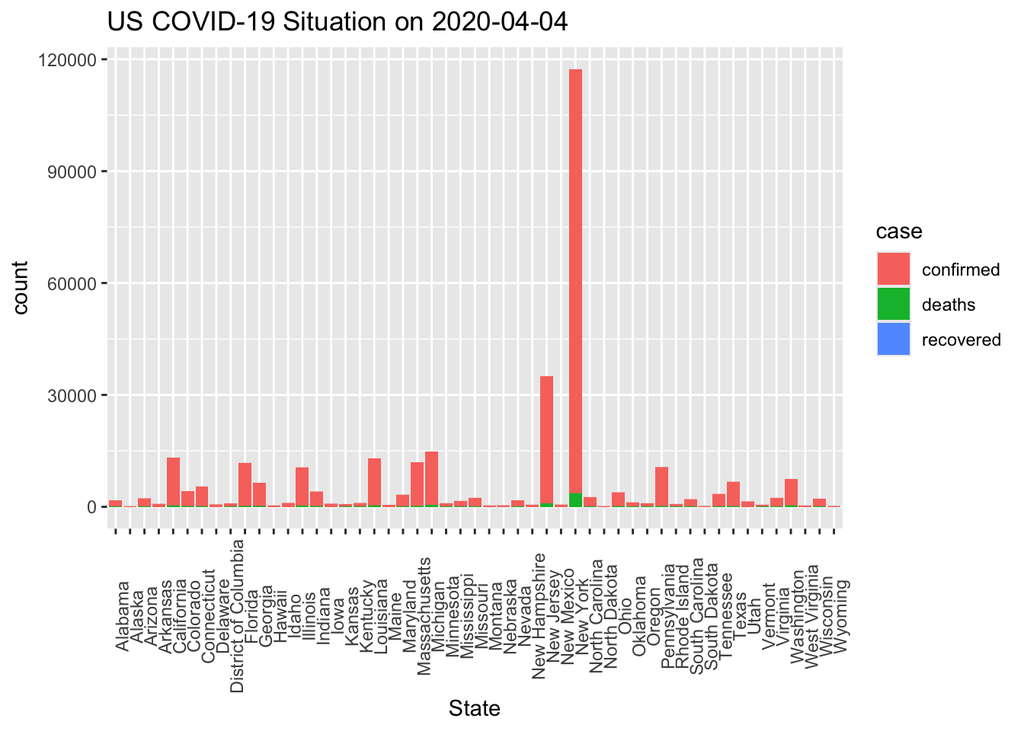

```r
county_count %>%
  # turn into long format for easy plotting
  pivot_longer(confirmed:recovered,
               names_to = "case",
               values_to = "count") %>%
  group_by(province_state) %>%
  ggplot() +
  geom_col(mapping = aes(x = province_state, y = `count`, fill = `case`)) +
  # scale_y_log10() +
  labs(title = "US COVID-19 Situation on 2020-04-04", x = "State") +
  theme(axis.text.x = element_text(angle = 90))
```

Read in the 2020 county-level health ranking data.

```r
county_info <- read_csv("~/Downloads/us-county-health-rankings-2020.csv.gz") %>%
  filter(!is.na(county)) %>%
  mutate(fips = as.numeric(fips)) %>%
  dplyr::select(fips,
         state,
         county,
         percent_fair_or_poor_health,
         percent_smokers,
         percent_adults_with_obesity,
         # food_environment_index,
         percent_with_access_to_exercise_opportunities,
         percent_excessive_drinking,
         # teen_birth_rate,
         percent_uninsured,
         # primary_care_physicians_rate,
         # preventable_hospitalization_rate,
         # high_school_graduation_rate,
         percent_some_college,
         percent_unemployed,
         percent_children_in_poverty,
         # `80th_percentile_income`,
         # `20th_percentile_income`,
         percent_single_parent_households,
         # violent_crime_rate,
         percent_severe_housing_problems,
         overcrowding,
         # life_expectancy,
         # age_adjusted_death_rate,
         percent_adults_with_diabetes,
         # hiv_prevalence_rate,
         percent_food_insecure,
         # percent_limited_access_to_healthy_foods,
         percent_insufficient_sleep,
         percent_uninsured_2,
         median_household_income,
         average_traffic_volume_per_meter_of_major_roadways,
         percent_homeowners,
         # percent_severe_housing_cost_burden,
         population_2,
         percent_less_than_18_years_of_age,
         percent_65_and_over,
         percent_black,
         percent_asian,
         percent_hispanic,
         percent_female,
         percent_rural) %>%
  print(width = Inf)
```

```
# A tibble: 3,142 × 30
    fips state   county   percent_fair_or_poor_health percent_smokers
   <dbl> <chr>   <chr>                          <dbl>           <dbl>
 1  1001 Alabama Autauga                         20.9            18.1
 2  1003 Alabama Baldwin                         17.5            17.5
 3  1005 Alabama Barbour                         29.6            22.0
 4  1007 Alabama Bibb                            19.4            19.1
 5  1009 Alabama Blount                          21.7            19.2
 6  1011 Alabama Bullock                         31.0            22.9
 7  1013 Alabama Butler                          27.9            21.8
 8  1015 Alabama Calhoun                         23.1            20.6
 9  1017 Alabama Chambers                        24.0            19.4
10  1019 Alabama Cherokee                        20.7            17.5
   percent_adults_with_obesity percent_with_access_to_exercise_opportunities
                         <dbl>                                         <dbl>
```

[output cut: 107 more lines]

For stability in estimating CFR, we restrict to counties with $\ge 5$ confirmed cases.

```r
county_count <- county_count %>%
  filter(confirmed >= 5)
```

We join the COVID-19 count data and county-level information using FIPS (Federal Information Processing System) as key.

```r
county_data <- county_count %>%
  left_join(county_info, by = "fips") %>%
  print(width = Inf)
```

```
# A tibble: 1,466 × 41
    fips admin2    province_state country_region last_update           lat
   <dbl> <chr>     <chr>          <chr>          <dttm>              <dbl>
 1 45001 Abbeville South Carolina US             2020-04-04 23:34:21  34.2
 2 22001 Acadia    Louisiana      US             2020-04-04 23:34:21  30.3
 3 51001 Accomack  Virginia       US             2020-04-04 23:34:21  37.8
 4 16001 Ada       Idaho          US             2020-04-04 23:34:21  43.5
 5 29001 Adair     Missouri       US             2020-04-04 23:34:21  40.2
 6 40001 Adair     Oklahoma       US             2020-04-04 23:34:21  35.9
 7  8001 Adams     Colorado       US             2020-04-04 23:34:21  39.9
 8 28001 Adams     Mississippi    US             2020-04-04 23:34:21  31.5
 9 31001 Adams     Nebraska       US             2020-04-04 23:34:21  40.5
10 42001 Adams     Pennsylvania   US             2020-04-04 23:34:21  39.9
    long_ confirmed deaths recovered active combined_key
    <dbl>     <dbl>  <dbl>     <dbl>  <dbl> <chr>
```

[output cut: 131 more lines]

Numerical summaries of each variable:

```r
summary(county_data)
```

```
      fips          admin2          province_state     country_region
 Min.   : 1001   Length:1466        Length:1466        Length:1466
 1st Qu.:18003   Class :character   Class :character   Class :character
 Median :29029   Mode  :character   Mode  :character   Mode  :character
 Mean   :30076
 3rd Qu.:42077
 Max.   :90053
 NA's   :13
  last_update                       lat            long_
 Min.   :2020-04-04 23:34:21   Min.   :19.60   Min.   :-159.60
 1st Qu.:2020-04-04 23:34:21   1st Qu.:33.96   1st Qu.: -94.56
 Median :2020-04-04 23:34:21   Median :38.02   Median : -86.48
 Mean   :2020-04-04 23:34:21   Mean   :37.71   Mean   : -89.73
 3rd Qu.:2020-04-04 23:34:21   3rd Qu.:41.38   3rd Qu.: -81.22
 Max.   :2020-04-04 23:34:21   Max.   :64.81   Max.   : -68.65
                               NA's   :19      NA's   :19
   confirmed           deaths           recovered     active
 Min.   :    5.0   Min.   :   0.000   Min.   :0   Min.   :0
 1st Qu.:    9.0   1st Qu.:   0.000   1st Qu.:0   1st Qu.:0
 Median :   20.0   Median :   0.000   Median :0   Median :0
 Mean   :  208.8   Mean   :   4.842   Mean   :0   Mean   :0
 3rd Qu.:   68.0   3rd Qu.:   2.000   3rd Qu.:0   3rd Qu.:0
 Max.   :63306.0   Max.   :1905.000   Max.   :0   Max.   :0

 combined_key          state              county
 Length:1466        Length:1466        Length:1466
 Class :character   Class :character   Class :character
 Mode  :character   Mode  :character   Mode  :character




 percent_fair_or_poor_health percent_smokers  percent_adults_with_obesity
 Min.   : 8.121              Min.   : 5.909   Min.   :12.40
 1st Qu.:14.390              1st Qu.:14.899   1st Qu.:29.10
 Median :17.010              Median :17.147   Median :32.95
 Mean   :17.594              Mean   :17.153   Mean   :32.41
 3rd Qu.:20.377              3rd Qu.:19.365   3rd Qu.:36.20
 Max.   :38.887              Max.   :27.775   Max.   :51.00
 NA's   :28                  NA's   :28       NA's   :28
```

[output cut: 57 more lines]

```
 Min.   : 7.722      Min.   : 0.1286   Min.   : 0.06245   Min.   : 0.7952
 1st Qu.:14.927      1st Qu.: 1.6174   1st Qu.: 0.68249   1st Qu.: 2.9419
 Median :17.222      Median : 5.6397   Median : 1.23421   Median : 5.5939
 Mean   :17.516      Mean   :12.4178   Mean   : 2.40412   Mean   :10.0011
 3rd Qu.:19.598      3rd Qu.:17.5931   3rd Qu.: 2.67550   3rd Qu.:11.0564
 Max.   :57.587      Max.   :81.9544   Max.   :42.95231   Max.   :96.3596
 NA's   :28          NA's   :28        NA's   :28         NA's   :28
 percent_female  percent_rural
 Min.   :34.63   Min.   :  0.00
 1st Qu.:50.00   1st Qu.: 17.11
 Median :50.66   Median : 36.97
 Mean   :50.46   Mean   : 40.11
 3rd Qu.:51.35   3rd Qu.: 60.00
 Max.   :56.87   Max.   :100.00
 NA's   :28      NA's   :28
```

List rows in `county_data` that don’t have a match in `county_count`:

```r
county_data %>%
  filter(is.na(state) & is.na(county)) %>%
  print(n = Inf)
```

```
# A tibble: 28 × 41
    fips admin2   province_state country_region last_update           lat  long_
   <dbl> <chr>    <chr>          <chr>          <dttm>              <dbl>  <dbl>
 1    NA DeKalb   Tennessee      US             2020-04-04 23:34:21  36.0  -85.8
 2    NA DeSoto   Florida        US             2020-04-04 23:34:21  27.2  -81.8
 3    NA Dukes a… Massachusetts  US             2020-04-04 23:34:21  41.4  -70.7
 4    NA Fillmore Minnesota      US             2020-04-04 23:34:21  43.7  -92.1
 5    NA Kansas … Missouri       US             2020-04-04 23:34:21  39.1  -94.6
 6    NA LaSalle  Illinois       US             2020-04-04 23:34:21  41.3  -88.9
 7    NA Manassas Virginia       US             2020-04-04 23:34:21  38.7  -77.5
 8    NA McDuffie Georgia        US             2020-04-04 23:34:21  33.5  -82.5
 9    NA Out of … Michigan       US             2020-04-04 23:34:21  NA     NA
10    NA Out of … Tennessee      US             2020-04-04 23:34:21  NA     NA
11 90005 Unassig… Arkansas       US             2020-04-04 23:34:21  NA     NA
12 90008 Unassig… Colorado       US             2020-04-04 23:34:21  NA     NA
```

[output cut: 23 more lines]

We found there are some rows that miss `fips`.

```r
county_count %>%
  filter(is.na(fips)) %>%
  dplyr::select(fips, admin2, province_state) %>%
  print(n = Inf)
```

```
# A tibble: 13 × 3
    fips admin2              province_state
   <dbl> <chr>               <chr>
 1    NA DeKalb              Tennessee
 2    NA DeSoto              Florida
 3    NA Dukes and Nantucket Massachusetts
 4    NA Fillmore            Minnesota
 5    NA Kansas City         Missouri
 6    NA LaSalle             Illinois
 7    NA Manassas            Virginia
 8    NA McDuffie            Georgia
 9    NA Out of MI           Michigan
10    NA Out of TN           Tennessee
11    NA Unassigned          Louisiana
12    NA Unassigned          Michigan
13    NA Weber               Utah
```

We need to (1) manually set the `fips` for some counties, (2) discard those `Unassigned`, `unassigned` or `Out of`, and (3) try to join with `county_info` again.

```r
county_data <- county_count %>%
  # manually set FIPS for some counties
  mutate(fips = ifelse(admin2 == "DeKalb" & province_state == "Tennessee", 47041, fips)) %>%
  mutate(fips = ifelse(admin2 == "DeSoto" & province_state == "Florida", 12027, fips)) %>%
  #mutate(fips = ifelse(admin2 == "Dona Ana" & province_state == "New Mexico", 35013, fips)) %>%
  mutate(fips = ifelse(admin2 == "Dukes and Nantucket" & province_state == "Massachusetts", 25019, fips)) %>%
  mutate(fips = ifelse(admin2 == "Fillmore" & province_state == "Minnesota", 27045, fips)) %>%
  #mutate(fips = ifelse(admin2 == "Harris" & province_state == "Texas", 48201, fips)) %>%
  #mutate(fips = ifelse(admin2 == "Kenai Peninsula" & province_state == "Alaska", 2122, fips)) %>%
  mutate(fips = ifelse(admin2 == "LaSalle" & province_state == "Illinois", 17099, fips)) %>%
  #mutate(fips = ifelse(admin2 == "LaSalle" & province_state == "Louisiana", 22059, fips)) %>%
  #mutate(fips = ifelse(admin2 == "Lac qui Parle" & province_state == "Minnesota", 27073, fips)) %>%
  mutate(fips = ifelse(admin2 == "Manassas" & province_state == "Virginia", 51683, fips)) %>%
  #mutate(fips = ifelse(admin2 == "Matanuska-Susitna" & province_state == "Alaska", 2170, fips)) %>%
  mutate(fips = ifelse(admin2 == "McDuffie" & province_state == "Georgia", 13189, fips)) %>%
  #mutate(fips = ifelse(admin2 == "McIntosh" & province_state == "Georgia", 13191, fips)) %>%
  #mutate(fips = ifelse(admin2 == "McKean" & province_state == "Pennsylvania", 42083, fips)) %>%
  mutate(fips = ifelse(admin2 == "Weber" & province_state == "Utah", 49057, fips)) %>%
  filter(!(is.na(fips) | str_detect(admin2, "Out of") | str_detect(admin2, "Unassigned"))) %>%
  left_join(county_info, by = "fips") %>%
  print(width = Inf)
```

```
# A tibble: 1,446 × 41
    fips admin2    province_state country_region last_update           lat
   <dbl> <chr>     <chr>          <chr>          <dttm>              <dbl>
 1 45001 Abbeville South Carolina US             2020-04-04 23:34:21  34.2
 2 22001 Acadia    Louisiana      US             2020-04-04 23:34:21  30.3
 3 51001 Accomack  Virginia       US             2020-04-04 23:34:21  37.8
 4 16001 Ada       Idaho          US             2020-04-04 23:34:21  43.5
 5 29001 Adair     Missouri       US             2020-04-04 23:34:21  40.2
 6 40001 Adair     Oklahoma       US             2020-04-04 23:34:21  35.9
 7  8001 Adams     Colorado       US             2020-04-04 23:34:21  39.9
 8 28001 Adams     Mississippi    US             2020-04-04 23:34:21  31.5
 9 31001 Adams     Nebraska       US             2020-04-04 23:34:21  40.5
10 42001 Adams     Pennsylvania   US             2020-04-04 23:34:21  39.9
    long_ confirmed deaths recovered active combined_key
    <dbl>     <dbl>  <dbl>     <dbl>  <dbl> <chr>
```

[output cut: 131 more lines]

Summarize again

```r
summary(county_data)
```

```
      fips          admin2          province_state     country_region
 Min.   : 1001   Length:1446        Length:1446        Length:1446
 1st Qu.:17186   Class :character   Class :character   Class :character
 Median :28156   Mode  :character   Mode  :character   Mode  :character
 Mean   :29455
 3rd Qu.:42048
 Max.   :56039
  last_update                       lat            long_
 Min.   :2020-04-04 23:34:21   Min.   :19.60   Min.   :-159.60
 1st Qu.:2020-04-04 23:34:21   1st Qu.:33.96   1st Qu.: -94.52
 Median :2020-04-04 23:34:21   Median :38.02   Median : -86.48
 Mean   :2020-04-04 23:34:21   Mean   :37.71   Mean   : -89.73
 3rd Qu.:2020-04-04 23:34:21   3rd Qu.:41.39   3rd Qu.: -81.21
 Max.   :2020-04-04 23:34:21   Max.   :64.81   Max.   : -68.65
   confirmed           deaths           recovered     active
 Min.   :    5.0   Min.   :   0.000   Min.   :0   Min.   :0
 1st Qu.:    9.0   1st Qu.:   0.000   1st Qu.:0   1st Qu.:0
 Median :   20.0   Median :   0.000   Median :0   Median :0
 Mean   :  207.2   Mean   :   4.854   Mean   :0   Mean   :0
 3rd Qu.:   66.0   3rd Qu.:   2.000   3rd Qu.:0   3rd Qu.:0
 Max.   :63306.0   Max.   :1905.000   Max.   :0   Max.   :0
 combined_key          state              county
 Length:1446        Length:1446        Length:1446
 Class :character   Class :character   Class :character
 Mode  :character   Mode  :character   Mode  :character



 percent_fair_or_poor_health percent_smokers  percent_adults_with_obesity
 Min.   : 8.121              Min.   : 5.909   Min.   :12.40
 1st Qu.:14.390              1st Qu.:14.899   1st Qu.:29.10
 Median :17.010              Median :17.143   Median :32.90
 Mean   :17.594              Mean   :17.151   Mean   :32.39
 3rd Qu.:20.398              3rd Qu.:19.365   3rd Qu.:36.20
 Max.   :38.887              Max.   :27.775   Max.   :51.00
 percent_with_access_to_exercise_opportunities percent_excessive_drinking
 Min.   :  0.00                                Min.   : 7.81
 1st Qu.: 59.95                                1st Qu.:15.68
 Median : 74.71                                Median :18.03
 Mean   : 71.15                                Mean   :17.91
```

[output cut: 43 more lines]

```
 Max.   :89.76      Max.   :10105518   Max.   :35.447
 percent_65_and_over percent_black     percent_asian      percent_hispanic
 Min.   : 7.722      Min.   : 0.1286   Min.   : 0.06245   Min.   : 0.7952
 1st Qu.:14.913      1st Qu.: 1.6168   1st Qu.: 0.68228   1st Qu.: 2.9451
 Median :17.225      Median : 5.6397   Median : 1.22863   Median : 5.6100
 Mean   :17.512      Mean   :12.4056   Mean   : 2.40009   Mean   :10.0338
 3rd Qu.:19.598      3rd Qu.:17.4904   3rd Qu.: 2.66813   3rd Qu.:11.1199
 Max.   :57.587      Max.   :81.9544   Max.   :42.95231   Max.   :96.3596
 percent_female  percent_rural
 Min.   :34.63   Min.   :  0.00
 1st Qu.:50.00   1st Qu.: 17.11
 Median :50.65   Median : 36.97
 Mean   :50.46   Mean   : 40.12
 3rd Qu.:51.35   3rd Qu.: 60.04
 Max.   :56.87   Max.   :100.00
```

If there are variables with missing value for many counties, we go back and remove those variables from consideration.

Let’s create a final data frame for analysis.

```r
county_data <- county_data %>%
  dplyr::mutate(state = as.factor(state)) %>%
  dplyr::select(county, confirmed, deaths, state, percent_fair_or_poor_health:percent_rural)
summary(county_data)
```

```
    county            confirmed           deaths                    state
 Length:1446        Min.   :    5.0   Min.   :   0.000   Georgia       :  96
 Class :character   1st Qu.:    9.0   1st Qu.:   0.000   Texas         :  80
 Mode  :character   Median :   20.0   Median :   0.000   North Carolina:  63
                    Mean   :  207.2   Mean   :   4.854   Mississippi   :  61
                    3rd Qu.:   66.0   3rd Qu.:   2.000   Indiana       :  58
                    Max.   :63306.0   Max.   :1905.000   Ohio          :  57
                                                         (Other)       :1031
 percent_fair_or_poor_health percent_smokers  percent_adults_with_obesity
 Min.   : 8.121              Min.   : 5.909   Min.   :12.40
 1st Qu.:14.390              1st Qu.:14.899   1st Qu.:29.10
 Median :17.010              Median :17.143   Median :32.90
 Mean   :17.594              Mean   :17.151   Mean   :32.39
 3rd Qu.:20.398              3rd Qu.:19.365   3rd Qu.:36.20
 Max.   :38.887              Max.   :27.775   Max.   :51.00

 percent_with_access_to_exercise_opportunities percent_excessive_drinking
 Min.   :  0.00                                Min.   : 7.81
 1st Qu.: 59.95                                1st Qu.:15.68
 Median : 74.71                                Median :18.03
 Mean   : 71.15                                Mean   :17.91
 3rd Qu.: 85.97                                3rd Qu.:20.01
 Max.   :100.00                                Max.   :28.62

 percent_uninsured percent_some_college percent_unemployed
 Min.   : 2.263    Min.   :21.14        Min.   : 1.582
 1st Qu.: 6.754    1st Qu.:53.21        1st Qu.: 3.252
 Median : 9.937    Median :61.19        Median : 3.870
 Mean   :10.592    Mean   :60.83        Mean   : 4.071
 3rd Qu.:13.527    3rd Qu.:68.72        3rd Qu.: 4.690
 Max.   :31.208    Max.   :90.34        Max.   :18.092

 percent_children_in_poverty percent_single_parent_households
 Min.   : 2.50               Min.   : 9.43
 1st Qu.:12.82               1st Qu.:27.07
 Median :18.40               Median :32.96
 Mean   :19.46               Mean   :33.83
 3rd Qu.:24.50               3rd Qu.:38.93
 Max.   :55.00               Max.   :80.00

```

[output cut: 32 more lines]

```
 percent_65_and_over percent_black     percent_asian      percent_hispanic
 Min.   : 7.722      Min.   : 0.1286   Min.   : 0.06245   Min.   : 0.7952
 1st Qu.:14.913      1st Qu.: 1.6168   1st Qu.: 0.68228   1st Qu.: 2.9451
 Median :17.225      Median : 5.6397   Median : 1.22863   Median : 5.6100
 Mean   :17.512      Mean   :12.4056   Mean   : 2.40009   Mean   :10.0338
 3rd Qu.:19.598      3rd Qu.:17.4904   3rd Qu.: 2.66813   3rd Qu.:11.1199
 Max.   :57.587      Max.   :81.9544   Max.   :42.95231   Max.   :96.3596

 percent_female  percent_rural
 Min.   :34.63   Min.   :  0.00
 1st Qu.:50.00   1st Qu.: 17.11
 Median :50.65   Median : 36.97
 Mean   :50.46   Mean   : 40.12
 3rd Qu.:51.35   3rd Qu.: 60.04
 Max.   :56.87   Max.   :100.00
```

```r
county_data %>%
  dplyr::mutate(cfr = deaths / confirmed) %>%
  dplyr::select(county, state, confirmed, deaths, cfr) %>%
  arrange(desc(cfr)) %>%
  top_n(10)
```

```
# A tibble: 18 × 5
   county         state          confirmed deaths   cfr
   <chr>          <fct>              <dbl>  <dbl> <dbl>
 1 Emmet          Michigan               7      2 0.286
 2 Grand Traverse Michigan              12      3 0.25
 3 Toole          Montana               12      3 0.25
 4 Fayette        Indiana               14      3 0.214
 5 Concordia      Louisiana              5      1 0.2
 6 Harrison       Texas                  5      1 0.2
 7 Huntington     Indiana                5      1 0.2
 8 Isabella       Michigan              10      2 0.2
 9 McDuffie       Georgia                5      1 0.2
10 Navarro        Texas                  5      1 0.2
11 Orange         Indiana                5      1 0.2
12 Perry          Pennsylvania           5      1 0.2
13 Randolph       Indiana                5      1 0.2
14 Rockingham     North Carolina         5      1 0.2
15 Seneca         Ohio                   5      1 0.2
16 Toombs         Georgia                5      1 0.2
17 Vigo           Indiana               10      2 0.2
18 Washington     Alabama                5      1 0.2
```

Write final data into a csv file for future use.

```r
write_csv(county_data, "~/Downloads/covid19-county-data-20200404.csv.gz")
```

### 1.3 Note:

Given that the datasets were collected in the middle of the pandemic, what assumptions of CFR might be violated by defining CFR as `deaths/confirmed` from this data set?

Because COVID-19 pandemic was still ongoing in 2020, we should realize some critical assumptions for defining CFR are not met using this datasets.

1. Numbers of confirmed cases do not reflect the number of diagnosed people. This is mainly limited by the availability of testing.
2. Some confirmed cases may die later.

With acknowledgement of these severe limitations, we continue to use `deaths/confirmed` as a very rough proxy of CFR.

### 1.4 Q1.1 (5pts)

Read and run above code to generate a data frame `county_data` that includes county-level COVID-19 confirmed cases and deaths, demographic, and health related information.

**Solution**

Displayed below is a generated data frame ‘county_data’ that includes county-level COVID-19 confirmed cases and deaths, demographic, and health related information. We are able to see that there are 1446 rows and 31 columns.

```r
county_data <- read_csv("~/Downloads/covid19-county-data-20200404.csv.gz") %>%
  print(width = Inf)
```

```
# A tibble: 1,446 × 31
   county    confirmed deaths state          percent_fair_or_poor_health
   <chr>         <dbl>  <dbl> <chr>                                <dbl>
 1 Abbeville         6      0 South Carolina                        19.9
 2 Acadia           65      2 Louisiana                             20.9
 3 Accomack          8      0 Virginia                              20.1
 4 Ada             360      3 Idaho                                 11.5
 5 Adair            10      0 Missouri                              21.4
 6 Adair            14      0 Oklahoma                              28.5
 7 Adams           294      9 Colorado                              16.6
 8 Adams            16      0 Mississippi                           27.3
 9 Adams             8      0 Nebraska                              15.8
10 Adams            21      0 Pennsylvania                          15.3
   percent_smokers percent_adults_with_obesity
             <dbl>                       <dbl>
```

[output cut: 119 more lines]

### 1.5 Q1.2(5pts)

What assumptions of logistic regression may be violated by this data set?

**Solution** There are several logistic regression assumptions that may be violated when modeling outcomes pertaining to, for instance, mortality from COVID-19 or the presence of a confirmed case of COVID-19 as we will explore later in the report. These assumptions are:

**1. Independence of Observations:** The observations (counties) should be independent. Because we do not know the full background of the dataset, we do not have information regarding whether the COVID-19 cases/deaths in nearby counties or states may be spatially correlated (potentially due to similar healthcare systems or government policies).

**3. No Outliers/Influential Points:** The urban counties (such as New York/Los Angeles) may have extreme COVID-19 case/death counts compared to other rural areas. Such outliers may affect the coefficient estimates.

**4. Adequate Sample Size:** There are only 1446 counties in the sample size. Although this sample size may be adequte, rare outcomes (such as deaths in low-population counties) may cause small-sample bias.

**5. Binary Outcome Requirement:** Logistic regression requires a binary outcome variable. Therefore, it is important to set up the outcome variable as having 2 outcomes: Success which is defined as “deaths” and Failure “confirmed-deaths). This woud be a valid binomial set up where each”trial” or confirmed case has a binary outcome (death or survival).

**6. Measurement Error in Outcomes:** There may be underreported deaths and confirmed cases (due to testing and resource limitations) which may introduce noise. The binomial logistic regression model assumes that the outcome is measured without error and so misclassification bias may distort results.

### 1.6 Q1.3 (10pts)

Run a logistic regression, using variables `state`, …, `percent_rural` as predictors.

**Solution**

We will run a logisitc regression where response variables are characterized as 1. deaths (success) and 2. living (faiure) which is characterized as the formula: confirmed-deaths. The binomial logistic regression model will esimate how each predictor affects the log-odds of a county having high deaths (success) versus low deaths (failure).

Fitting the Binomial Logistic Regression Model:

Note that we will exclude the variable “county” in our model because county names are identifiers, not meaningful predictors. Including them would cause perfect multicollinearity because each county is unique.

```r
excluded_predictors <- c("county", "confirmed", "deaths")
predictors <- setdiff(names(county_data), excluded_predictors)

formula <- as.formula(
  paste("cbind(deaths, confirmed - deaths) ~", paste(predictors, collapse = " + "))
)

model_1 <- glm(formula, family = binomial(link = "logit"), data = county_data)

model_summary <- summary(model_1)
coef_table <- as.data.frame(model_summary$coefficients)
```

```r
model_summary
```

```
Call:
glm(formula = formula, family = binomial(link = "logit"), data = county_data)

Coefficients:
                                                     Estimate Std. Error
(Intercept)                                         1.682e+00  1.625e+00
stateAlaska                                        -8.493e-01  1.041e+00
stateArizona                                        6.061e-01  3.670e-01
stateArkansas                                      -1.177e+00  4.946e-01
stateCalifornia                                     2.053e-01  3.240e-01
stateColorado                                       4.335e-01  2.642e-01
stateConnecticut                                    4.387e-02  2.508e-01
stateDelaware                                      -6.062e-01  3.565e-01
stateDistrict of Columbia                          -1.359e+00  5.202e-01
stateFlorida                                        2.603e-01  2.396e-01
stateGeorgia                                        2.200e-01  1.965e-01
stateHawaii                                        -1.672e+00  7.030e-01
stateIdaho                                         -6.081e-01  4.250e-01
stateIllinois                                       1.492e-01  2.240e-01
stateIndiana                                        4.063e-01  2.205e-01
stateIowa                                          -4.926e-01  3.933e-01
stateKansas                                         3.751e-01  3.367e-01
stateKentucky                                       3.673e-01  2.681e-01
stateLouisiana                                      1.264e-01  2.126e-01
stateMaine                                         -5.892e-01  4.451e-01
stateMaryland                                      -7.426e-01  2.627e-01
stateMassachusetts                                 -9.027e-01  2.649e-01
stateMichigan                                       2.331e-01  2.081e-01
stateMinnesota                                     -3.288e-01  3.327e-01
stateMississippi                                    2.270e-01  2.442e-01
stateMissouri                                      -3.473e-01  2.588e-01
stateMontana                                       -5.572e-02  4.675e-01
stateNebraska                                      -2.718e-01  5.581e-01
stateNevada                                         2.790e-01  2.829e-01
stateNew Hampshire                                 -1.910e+00  6.172e-01
stateNew Jersey                                     1.841e-02  2.213e-01
stateNew Mexico                                     7.225e-01  5.644e-01
stateNew York                                      -9.251e-01  2.466e-01
stateNorth Carolina                                -6.333e-01  2.474e-01
stateNorth Dakota                                  -9.169e-01  7.659e-01
```

[output cut: 117 more lines]

```
percent_black                                        1.493 0.135505
percent_asian                                       -0.098 0.922197
percent_hispanic                                    -2.285 0.022327 *
percent_female                                       1.774 0.076027 .
percent_rural                                        0.524 0.599962
---
Signif. codes:  0 '***' 0.001 '**' 0.01 '*' 0.05 '.' 0.1 ' ' 1

(Dispersion parameter for binomial family taken to be 1)

    Null deviance: 3257.7  on 1445  degrees of freedom
Residual deviance: 1842.8  on 1368  degrees of freedom
AIC: 3880.6

Number of Fisher Scoring iterations: 14
```

```r
coef_table
```

```
                                                        Estimate   Std. Error
(Intercept)                                         1.681833e+00 1.625198e+00
stateAlaska                                        -8.492907e-01 1.041484e+00
stateArizona                                        6.061120e-01 3.670057e-01
stateArkansas                                      -1.177299e+00 4.946218e-01
stateCalifornia                                     2.053367e-01 3.239502e-01
stateColorado                                       4.334934e-01 2.641755e-01
stateConnecticut                                    4.386562e-02 2.508354e-01
stateDelaware                                      -6.062028e-01 3.565265e-01
stateDistrict of Columbia                          -1.359357e+00 5.202309e-01
stateFlorida                                        2.602717e-01 2.396238e-01
stateGeorgia                                        2.200332e-01 1.964584e-01
stateHawaii                                        -1.672370e+00 7.030327e-01
stateIdaho                                         -6.080688e-01 4.249782e-01
stateIllinois                                       1.492355e-01 2.240423e-01
stateIndiana                                        4.062550e-01 2.204527e-01
stateIowa                                          -4.925753e-01 3.933062e-01
stateKansas                                         3.750868e-01 3.366575e-01
stateKentucky                                       3.672974e-01 2.681057e-01
stateLouisiana                                      1.264148e-01 2.125676e-01
stateMaine                                         -5.891862e-01 4.450725e-01
stateMaryland                                      -7.426454e-01 2.626826e-01
stateMassachusetts                                 -9.027371e-01 2.648695e-01
stateMichigan                                       2.331141e-01 2.080708e-01
stateMinnesota                                     -3.288359e-01 3.326937e-01
stateMississippi                                    2.269677e-01 2.441595e-01
stateMissouri                                      -3.473099e-01 2.587720e-01
stateMontana                                       -5.572497e-02 4.675305e-01
stateNebraska                                      -2.717841e-01 5.580891e-01
stateNevada                                         2.789665e-01 2.828746e-01
stateNew Hampshire                                 -1.910236e+00 6.171611e-01
stateNew Jersey                                     1.841233e-02 2.212971e-01
stateNew Mexico                                     7.225061e-01 5.643633e-01
stateNew York                                      -9.250907e-01 2.466207e-01
stateNorth Carolina                                -6.332771e-01 2.473678e-01
stateNorth Dakota                                  -9.169044e-01 7.659469e-01
stateOhio                                          -6.816670e-02 2.334486e-01
stateOklahoma                                       8.480411e-01 2.916476e-01
stateOregon                                         5.792532e-02 3.179028e-01
statePennsylvania                                  -8.069241e-01 2.299776e-01
```

[output cut: 103 more lines]

```
percent_adults_with_diabetes                       -1.57018188 1.163728e-01
percent_food_insecure                              -1.99831405 4.568262e-02
percent_insufficient_sleep                          4.46195233 8.121630e-06
percent_uninsured_2                                 1.67965463 9.302453e-02
median_household_income                            -3.26561524 1.092266e-03
average_traffic_volume_per_meter_of_major_roadways  0.33562969 7.371501e-01
percent_homeowners                                 -5.52916760 3.217538e-08
population_2                                       -2.09986276 3.574092e-02
percent_less_than_18_years_of_age                  -2.96391461 3.037526e-03
percent_65_and_over                                 0.81253203 4.164864e-01
percent_black                                       1.49273960 1.355054e-01
percent_asian                                      -0.09766642 9.221972e-01
percent_hispanic                                   -2.28475700 2.232708e-02
percent_female                                      1.77421772 7.602714e-02
percent_rural                                       0.52445576 5.999616e-01
```

### 1.7 Q1.4 (10pts)

Interpret the regression coefficients of 3 significant predictors with p-value <0.05.

**Solution**

We first filtered out all the predictors with p-value <0.05 (excluded the intercept of the model). Next, we extracted the top 3 most significant predictors.

```r
significant_predictors <- coef_table %>%
  filter(`Pr(>|z|)` < 0.05 & rownames(coef_table) != "(Intercept)") %>%
  arrange(`Pr(>|z|)`)

top_5_predictors <- head(significant_predictors, 5)
print(top_5_predictors)
```

```
                                   Estimate  Std. Error   z value     Pr(>|z|)
percent_homeowners              -0.03398152 0.006145865 -5.529168 3.217538e-08
stateVirginia                   -1.53273214 0.317816271 -4.822699 1.416288e-06
percent_insufficient_sleep       0.04437542 0.009945291  4.461952 8.121630e-06
percent_severe_housing_problems -0.04473908 0.010759275 -4.158187 3.207828e-05
percent_children_in_poverty      0.03026591 0.007658195  3.952094 7.747036e-05
```

1. **percent_homeowners**: (Regression coefficient: -0.03398152 with a p-value of 3.217538e-08. Interpretation: A one percent increase in the homeownership rate is associated with a 0.03398152 decrease in the log-odds of COVID-19 deaths, holding all other predictors constants. In other words, a one percent increase in the homeownership rate is associated with a decrease in the odds of COVID-19 deaths by 3.3 percent, holding all other predictors constant. We are able to say that counties with high homeownership rates showed significantly lower COVID-19 mortality.
2. **percent_severe_housing_problems**: (Regression coefficient: -0.04473908) with a p-value of 3.207828e-05. Interpretation: A one percent increase in severe housing problems is associated with a 0.04473 decrease in the log-odds of COVID-19 deaths, holding all other predictors constant. In other words, a one percent increase in the severe housing problems is associated with a decrease in the odds of COVID-19 deaths by 4.37 percent, holding all other predictors constant. We are able to say that counties with high severe housing problems showed significantly lower COVID-19 mortality.
3. **percent_insufficient_sleep**: (Regression coefficient: 0.04437542) with a p-value of 8.121630e-06. Interpretation: A one percent increase in the percentage of people who do not get enough sleep is associated with a 0.04437 increase in the log odds of COVID-19 deaths, holding all other predictors constant. in other words, a one percent increase in sleep-derived population is associated with an increase in the odds of COVID-19 deaths by 4.5 percent, holding all other predictor constant. We are able to say that sleep derprivation appears to be a significant risk factor associated with COVID-19 deaths.

### 1.8 Q1.5 (10pts)

Apply analysis of deviance to (1) evaluate the goodness of fit of the model and (2) compare the model to the intercept-only model.

**Solution**

1. Likelihood Ratio Test (Comparison of the Current Model versus Intercept-Only Model): We will test whether the binomial logistic regression model is significantly better than the intercept-only model. In other words, we will evaluate whether the predictors collectively improve the model over a baseline (intercept-only) model. The p-value comes out to be < 2.2e-16 which is significantly less than 0.05. Therefore, we can conclude that our current logisitic regression model with the included predictors significantly improves the fit over a baseline (intercept-only) model. This indicates that at least one predictor variable is associated with COVID-19 mortality.

```r
null_model <- glm(
  cbind(deaths, confirmed - deaths) ~ 1,
  family = binomial,
  data = county_data
)

anova(null_model, model_1, test = "Chisq")
```

```
Analysis of Deviance Table

Model 1: cbind(deaths, confirmed - deaths) ~ 1
Model 2: cbind(deaths, confirmed - deaths) ~ state + percent_fair_or_poor_health +
    percent_smokers + percent_adults_with_obesity + percent_with_access_to_exercise_opportunities +
    percent_excessive_drinking + percent_uninsured + percent_some_college +
    percent_unemployed + percent_children_in_poverty + percent_single_parent_households +
    percent_severe_housing_problems + overcrowding + percent_adults_with_diabetes +
    percent_food_insecure + percent_insufficient_sleep + percent_uninsured_2 +
    median_household_income + average_traffic_volume_per_meter_of_major_roadways +
    percent_homeowners + population_2 + percent_less_than_18_years_of_age +
    percent_65_and_over + percent_black + percent_asian + percent_hispanic +
    percent_female + percent_rural
  Resid. Df Resid. Dev Df Deviance  Pr(>Chi)
1      1445     3257.7
2      1368     1842.8 77   1414.9 < 2.2e-16 ***
---
Signif. codes:  0 '***' 0.001 '**' 0.01 '*' 0.05 '.' 0.1 ' ' 1
```

```r
p_value <- 1 - pchisq(model_1$deviance, model_1$df.residual)
cat("Goodness-of-fit p-value:", p_value)
```

```
Goodness-of-fit p-value: 1.110223e-16
```

Effect Size: Pseudo R^2: We will next quantify the variance explained by the McFadden’s pseudo-R^2. We are able to conclude that the predictors explain around 43.433 percent of the deviance which indicates moderate to strong explanatory power.

```r
library(pscl)
pseudo_r2 <- 1 - (model_1$deviance / model_1$null.deviance)
cat("Pseudo-R²:", pseudo_r2)
```

```
Pseudo-R²: 0.4343347
```

### 1.9 Q1.6 (10pts)

Perform analysis of deviance to evaluate the significance of each predictor. Display the 10 most significant predictors.

**Solution**

The anova() function will conduct Type II liklihood Ratio tests to assess each predictor’s contribution while accounting for all other variables in the model. The table below showcases the Chi-square statistics, degrees of freedom, and p-values. Some of the predictors that are highly significant include: state, percent_homeowners, percent_insufficient_sleep, percent_severe_housing_problems, percent_children_in_poverty, median_household_income, etc.

```r
anova_results <- Anova(model_1, test = "LR", type = "II")
```

```r
significant_predictors <- as.data.frame(anova_results) %>%
  arrange(`Pr(>Chisq)`) %>%
  head(10)
print(significant_predictors)
```

```
                                    LR Chisq Df   Pr(>Chisq)
state                             571.076667 50 1.491062e-89
percent_homeowners                 30.984116  1 2.601488e-08
percent_insufficient_sleep         19.993884  1 7.769024e-06
percent_severe_housing_problems    17.155368  1 3.444346e-05
percent_children_in_poverty        15.666979  1 7.553140e-05
median_household_income            10.700584  1 1.071017e-03
percent_some_college                9.254634  1 2.349003e-03
percent_fair_or_poor_health         8.797733  1 3.016051e-03
percent_less_than_18_years_of_age   8.750920  1 3.094459e-03
percent_smokers                     6.022785  1 1.412235e-02
```

### 1.10 Q1.7 (5pts)

Construct confidence intervals of regression coefficients.

**Solution** In order to compute the confidence intervals for the regression coefficients in the binomial logistic regression model, we will utilize the confint() function. The results below showcase the lower and upper bounds of the coefficients at a specified confidence level (95 percent).

```r
confint(model_1)
```

```
                                                           2.5 %        97.5 %
(Intercept)                                        -1.540685e+00  4.829928e+00
stateAlaska                                        -3.753299e+00  7.665854e-01
stateArizona                                       -1.121919e-01  1.326975e+00
stateArkansas                                      -2.272222e+00 -2.941005e-01
stateCalifornia                                    -4.270811e-01  8.432042e-01
stateColorado                                      -8.047425e-02  9.558273e-01
stateConnecticut                                   -4.431493e-01  5.408817e-01
stateDelaware                                      -1.343063e+00  6.491602e-02
stateDistrict of Columbia                          -2.385522e+00 -3.452739e-01
stateFlorida                                       -2.045630e-01  7.356315e-01
stateGeorgia                                       -1.575974e-01  6.138168e-01
stateHawaii                                        -3.239788e+00 -4.080654e-01
stateIdaho                                         -1.491142e+00  1.890745e-01
stateIllinois                                      -2.839137e-01  5.952862e-01
stateIndiana                                       -2.054079e-02  8.447684e-01
stateIowa                                          -1.301477e+00  2.507241e-01
stateKansas                                        -3.042060e-01  1.020971e+00
stateKentucky                                      -1.643561e-01  8.894116e-01
stateLouisiana                                     -2.837727e-01  5.505662e-01
stateMaine                                         -1.538751e+00  2.289083e-01
stateMaryland                                      -1.256754e+00 -2.257937e-01
stateMassachusetts                                 -1.418191e+00 -3.792222e-01
stateMichigan                                      -1.674387e-01  6.492574e-01
stateMinnesota                                     -9.984654e-01  3.106177e-01
stateMississippi                                   -2.569089e-01  7.032953e-01
stateMissouri                                      -8.618337e-01  1.558494e-01
stateMontana                                       -1.068580e+00  7.935561e-01
stateNebraska                                      -1.524163e+00  7.176783e-01
stateNevada                                        -2.755078e-01  8.345940e-01
stateNew Hampshire                                 -3.354740e+00 -8.509625e-01
stateNew Jersey                                    -4.091492e-01  4.592997e-01
stateNew Mexico                                    -4.112221e-01  1.809014e+00
stateNew York                                      -1.403926e+00 -4.363713e-01
stateNorth Carolina                                -1.123934e+00 -1.511085e-01
stateNorth Dakota                                  -2.782881e+00  3.734572e-01
stateOhio                                          -5.211860e-01  3.949778e-01
stateOklahoma                                       2.753046e-01  1.419962e+00
stateOregon                                        -5.767115e-01  6.730255e-01
statePennsylvania                                  -1.252486e+00 -3.499987e-01
```

[output cut: 24 more lines]

```
percent_adults_with_diabetes                       -4.908876e-02  5.180565e-03
percent_food_insecure                              -1.891933e-01 -2.105405e-03
percent_insufficient_sleep                          2.490233e-02  6.388899e-02
percent_uninsured_2                                -1.936819e-02  2.612330e-01
median_household_income                            -1.735930e-05 -4.342325e-06
average_traffic_volume_per_meter_of_major_roadways -7.390708e-05  1.048167e-04
percent_homeowners                                 -4.605639e-02 -2.196463e-02
population_2                                       -6.804682e-08 -2.338900e-09
percent_less_than_18_years_of_age                  -7.990811e-02 -1.626028e-02
percent_65_and_over                                -1.360161e-02  3.253736e-02
percent_black                                      -2.712684e-03  2.024150e-02
percent_asian                                      -1.233780e-02  1.112980e-02
percent_hispanic                                   -3.569677e-02 -2.750001e-03
percent_female                                     -4.049216e-03  1.044219e-01
percent_rural                                      -2.958610e-03  5.070711e-03
```

```r
confint.default(model_1)
```

```
                                                           2.5 %        97.5 %
(Intercept)                                        -1.503495e+00  4.867162e+00
stateAlaska                                        -2.890561e+00  1.191980e+00
stateArizona                                       -1.132060e-01  1.325430e+00
stateArkansas                                      -2.146740e+00 -2.078584e-01
stateCalifornia                                    -4.295941e-01  8.402675e-01
stateColorado                                      -8.428110e-02  9.512679e-01
stateConnecticut                                   -4.477628e-01  5.354941e-01
stateDelaware                                      -1.304982e+00  9.257632e-02
stateDistrict of Columbia                          -2.378991e+00 -3.397231e-01
stateFlorida                                       -2.093824e-01  7.299258e-01
stateGeorgia                                       -1.650183e-01  6.050846e-01
stateHawaii                                        -3.050288e+00 -2.944508e-01
stateIdaho                                         -1.441011e+00  2.248731e-01
stateIllinois                                      -2.898793e-01  5.883503e-01
stateIndiana                                       -2.582424e-02  8.383343e-01
stateIowa                                          -1.263441e+00  2.782907e-01
stateKansas                                        -2.847498e-01  1.034923e+00
stateKentucky                                      -1.581801e-01  8.927749e-01
stateLouisiana                                     -2.902101e-01  5.430396e-01
stateMaine                                         -1.461512e+00  2.831398e-01
stateMaryland                                      -1.257494e+00 -2.277970e-01
stateMassachusetts                                 -1.421872e+00 -3.836025e-01
stateMichigan                                      -1.746972e-01  6.409253e-01
stateMinnesota                                     -9.809037e-01  3.232318e-01
stateMississippi                                   -2.515761e-01  7.055114e-01
stateMissouri                                      -8.544937e-01  1.598739e-01
stateMontana                                       -9.720679e-01  8.606180e-01
stateNebraska                                      -1.365619e+00  8.220503e-01
stateNevada                                        -2.754575e-01  8.333905e-01
stateNew Hampshire                                 -3.119849e+00 -7.006221e-01
stateNew Jersey                                    -4.153221e-01  4.521468e-01
stateNew Mexico                                    -3.836256e-01  1.828638e+00
stateNew York                                      -1.408458e+00 -4.417230e-01
stateNorth Carolina                                -1.118109e+00 -1.484451e-01
stateNorth Dakota                                  -2.418133e+00  5.843238e-01
stateOhio                                          -5.257176e-01  3.893842e-01
stateOklahoma                                       2.764224e-01  1.419660e+00
stateOregon                                        -5.651527e-01  6.810034e-01
statePennsylvania                                  -1.257672e+00 -3.561763e-01
```

[output cut: 24 more lines]

```
percent_adults_with_diabetes                       -4.888327e-02  5.397461e-03
percent_food_insecure                              -1.889169e-01 -1.830335e-03
percent_insufficient_sleep                          2.488300e-02  6.386783e-02
percent_uninsured_2                                -2.008250e-02  2.607570e-01
median_household_income                            -1.735225e-05 -4.335594e-06
average_traffic_volume_per_meter_of_major_roadways -7.404991e-05  1.046512e-04
percent_homeowners                                 -4.602720e-02 -2.193585e-02
population_2                                       -6.804068e-08 -2.344634e-09
percent_less_than_18_years_of_age                  -7.994758e-02 -1.630085e-02
percent_65_and_over                                -1.350320e-02  3.262726e-02
percent_black                                      -2.735887e-03  2.021771e-02
percent_asian                                      -1.231764e-02  1.114832e-02
percent_hispanic                                   -3.567572e-02 -2.729796e-03
percent_female                                     -5.141827e-03  1.033696e-01
percent_rural                                      -2.940223e-03  5.088614e-03
```

### 1.11 Q1.8 (5pts)

Plot the deviance residuals against the fitted values. Are there potential outliers?

**Solution**

The deviance residuals measure the discrepancy between the observed and predicted values in a binomial logistic regression model. In this analysis, we extract the fitted values and deviance residuals from the model and visualize them to assess model fit. The plot reveals a few potential outliers—specifically, observations that deviate substantially from the horizontal red dashed line at y=0, which serves as the baseline for well-fitted points. It is important to note that the points that are far from 0 (top/bottom of the plot) and are positive represent counties where the model underpredicted the chance of death or overpredicted the chance of death (if the residuals are negative.) However, we are able to conclude that the majority of the deviance residuals are randomly scattered around the red dashed line (no specific pattern of the deviance residuals). A smoothed trend line is also included, which curves slightly downward, indicating a mild non-linearity that may suggest model misspecification. We explore these flagged observations in more detail in the subsequent section through a table.

```r
dev_residuals <- residuals(model_1, type = "deviance")
fitted_values <- fitted(model_1)
```

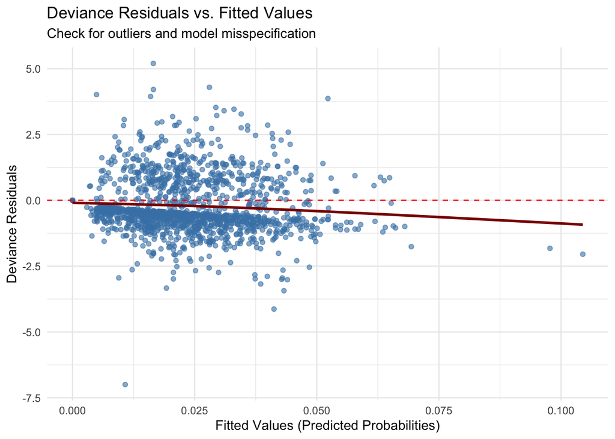

```r
ggplot(data = NULL, aes(x = fitted_values, y = dev_residuals)) +
  geom_point(alpha = 0.6, color = "steelblue") +
  geom_hline(yintercept = 0, linetype = "dashed", color = "red") +
  geom_smooth(se = FALSE, color = "darkred") +
  labs(
    x = "Fitted Values (Predicted Probabilities)",
    y = "Deviance Residuals",
    title = "Deviance Residuals vs. Fitted Values",
    subtitle = "Check for outliers and model misspecification"
  ) +
  theme_minimal()
```

Explanation of the Table:

The table showcases the top deviance residual outliers from the binomial regression model we created earlier. The counties with the largest absolute deviance residuals are listed from top to bottom (difference between the observed and predicted number of deaths was substantial.) The model flagged 51 counties as outliers (based on a threshold of |residual| > 2.5) where Westchester County, New York had 67 deaths out of 13081 confirmed cases. Despite its large population and case count, the model’s predicted probability of death deviates from the oberved outcome, causing the large residual. In addition, other counties such as Hampden and Franklin in Massachusetts had moderate confirmed cases but a high number of deaths, causing greater residuals due to underestimation of number of deaths from the model predictions.

```r
analysis_df <- data.frame(
  dev_residual = dev_residuals,
  fitted = fitted_values,
  county = county_data$county,
  state = county_data$state,
  deaths = county_data$deaths,
  confirmed = county_data$confirmed
)

outliers_df <- analysis_df %>%
  mutate(outlier = ifelse(abs(dev_residual) > 2.5, "Yes", "No")) %>%
  filter(outlier == "Yes") %>%
  arrange(desc(abs(dev_residual)))

print(outliers_df[, c("county", "state", "dev_residual", "fitted", "confirmed", "deaths")])
```

```
                   county          state dev_residual      fitted confirmed
1387          Westchester       New York    -6.997301 0.010796621     13081
535               Hampden  Massachusetts     5.199214 0.016542718       733
460              Franklin  Massachusetts     4.294001 0.028025919        95
534              Hamilton      Tennessee     4.209629 0.016560948        71
1019               Pierce     Washington    -4.131013 0.041244898       620
1380                 Webb          Texas     4.016335 0.004918054        83
512                Greene       Missouri     3.943966 0.015986524        64
684                  King     Washington     3.866179 0.052280956      2898
252                Clarke        Georgia     3.526730 0.029337975        60
852                 Miami           Ohio     3.459996 0.033053201        69
1371            Washtenaw       Michigan    -3.434615 0.043274950       501
1203 St. John the Baptist      Louisiana     3.404152 0.031022410       338
1235              Suffolk  Massachusetts    -3.333595 0.019220182      2429
798               Madison        Indiana     3.279931 0.034533844        72
```

[output cut: 89 more lines]

### 1.12 Q1.9 (5pts)

Plot the half-normal plot. Are there potential outliers in predictor space?

**Solution**

In order to identify potential outliers in the predictor space (unusual combinations of predictor variables), we created a half normal plot of the hat values (leverage) from the binomial logistic regression model created. These hat values measure how far each observation’s predictor values are from the average predictor values in the dataset. Identifying high leverage points is essential as they can disproportionately influence the model’s fit even if they don’t have large residuals.

```r
hat_values <- hatvalues(model_1)
```

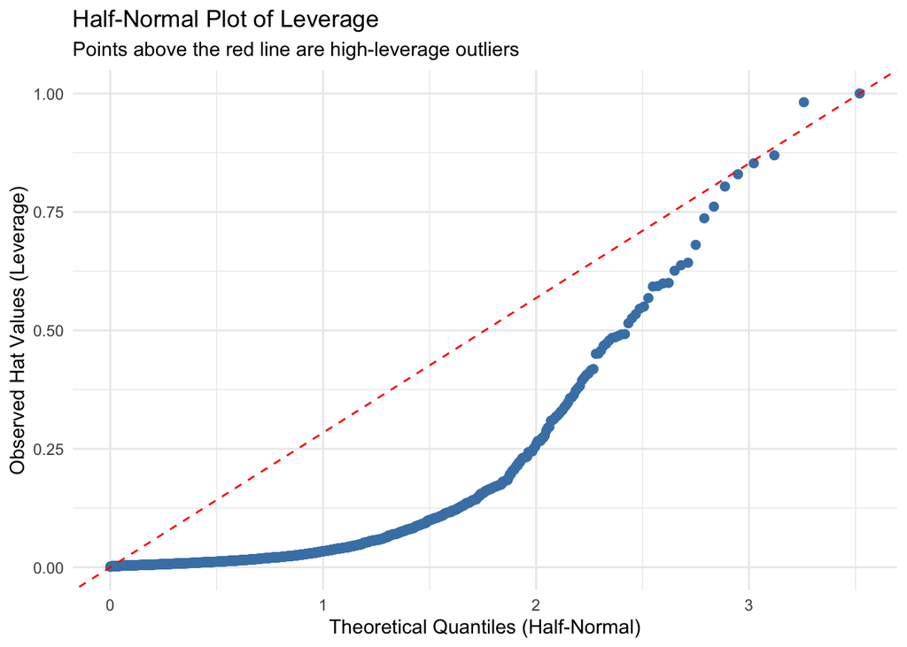

```r
n <- length(hat_values)
expected_quantiles <- qnorm((1:n + n - 1/8) / (2*n + 1/2))

ggplot(data = NULL, aes(x = expected_quantiles, y = sort(hat_values))) +
  geom_point(color = "steelblue", size = 2) +
  geom_abline(slope = max(hat_values) / max(expected_quantiles),
              intercept = 0,
              linetype = "dashed", color = "red") +
  labs(
    x = "Theoretical Quantiles (Half-Normal)",
    y = "Observed Hat Values (Leverage)",
    title = "Half-Normal Plot of Leverage",
    subtitle = "Points above the red line are high-leverage outliers"
  ) +
  theme_minimal()
```

```r
leverage_analysis <- data.frame(
  county = county_data$county,
  state = county_data$state,
  hat_value = hatvalues(model_1)
)

p <- length(coef(model_1)) - 1
n <- nrow(county_data)
leverage_threshold <- (2 * p) / n

high_leverage_outliers <- leverage_analysis %>%
  mutate(high_leverage = ifelse(hat_value > leverage_threshold, "Yes", "No")) %>%
  filter(high_leverage == "Yes") %>%
  arrange(desc(hat_value))

print(high_leverage_outliers[, c("county", "state", "hat_value")])
```

```
                   county                state hat_value
367  District of Columbia District of Columbia 1.0000000
931              New York             New York 0.9815933
247                 Clark               Nevada 0.8694759
776           Los Angeles           California 0.8527985
584              Honolulu               Hawaii 0.8295493
300                  Cook             Illinois 0.8036797
1058           Providence         Rhode Island 0.7612795
1375                Wayne             Michigan 0.7366173
926            New Castle             Delaware 0.6805068
684                  King           Washington 0.6428217
975               Orleans            Louisiana 0.6375359
811              Maricopa              Arizona 0.6258847
423                 Essex           New Jersey 0.6002219
429             Fairfield          Connecticut 0.5991634
```

[output cut: 164 more lines]

### 1.13 Q1.10 (10pts)

Find the best sub-model using the AIC criterion.

**Solution**

To identify the optimal subset of predictors from the binomial logistic regression model, we will utilize stepwise selection with AIC which balances the model fit and the complexity, favoring models with fewer predictors.

```r
best_model <- stepAIC(
  model_1,
  direction = "both",
  trace = FALSE
)
```

```r
full_formula <- formula(model_1)
full_aic <- AIC(model_1)

best_formula <- formula(best_model)
best_aic <- AIC(best_model)

cat("FULL MODEL:\n")
```

```
FULL MODEL:
```

```r
print(full_formula)
```

```
cbind(deaths, confirmed - deaths) ~ state + percent_fair_or_poor_health +
    percent_smokers + percent_adults_with_obesity + percent_with_access_to_exercise_opportunities +
    percent_excessive_drinking + percent_uninsured + percent_some_college +
    percent_unemployed + percent_children_in_poverty + percent_single_parent_households +
    percent_severe_housing_problems + overcrowding + percent_adults_with_diabetes +
    percent_food_insecure + percent_insufficient_sleep + percent_uninsured_2 +
    median_household_income + average_traffic_volume_per_meter_of_major_roadways +
    percent_homeowners + population_2 + percent_less_than_18_years_of_age +
    percent_65_and_over + percent_black + percent_asian + percent_hispanic +
    percent_female + percent_rural
```

```r
cat("AIC:", full_aic, "\n\n")
```

```
AIC: 3880.648
```

```r
cat("BEST MODEL (by AIC):\n")
```

```
BEST MODEL (by AIC):
```

```r
print(best_formula)
```

```
cbind(deaths, confirmed - deaths) ~ state + percent_fair_or_poor_health +
    percent_smokers + percent_excessive_drinking + percent_uninsured +
    percent_some_college + percent_unemployed + percent_children_in_poverty +
    percent_single_parent_households + percent_severe_housing_problems +
    percent_adults_with_diabetes + percent_food_insecure + percent_insufficient_sleep +
    percent_uninsured_2 + median_household_income + percent_homeowners +
    population_2 + percent_less_than_18_years_of_age + percent_black +
    percent_hispanic + percent_female
```

```r
cat("AIC:", best_aic, "\n")
```

```
AIC: 3870.062
```

```r
cat("Difference in AIC:", best_aic - full_aic, "\n")
```

```
Difference in AIC: -10.58625
```

```r
library(dplyr)
comparison <- data.frame(
  Model = c("Full", "Best"),
  Predictors = c(
    paste(length(attr(terms(model_1), "term.labels")), "predictors"),
    paste(length(attr(terms(best_model), "term.labels")), "predictors")
  ),
  AIC = c(full_aic, best_aic)
)
print(comparison)
```

```
  Model    Predictors      AIC
1  Full 28 predictors 3880.648
2  Best 21 predictors 3870.062
```

```r
summary(best_model)
```

```
Call:
glm(formula = cbind(deaths, confirmed - deaths) ~ state + percent_fair_or_poor_health +
    percent_smokers + percent_excessive_drinking + percent_uninsured +
    percent_some_college + percent_unemployed + percent_children_in_poverty +
    percent_single_parent_households + percent_severe_housing_problems +
    percent_adults_with_diabetes + percent_food_insecure + percent_insufficient_sleep +
    percent_uninsured_2 + median_household_income + percent_homeowners +
    population_2 + percent_less_than_18_years_of_age + percent_black +
    percent_hispanic + percent_female, family = binomial(link = "logit"),
    data = county_data)

Coefficients:
                                    Estimate Std. Error z value Pr(>|z|)
(Intercept)                        2.021e+00  1.433e+00   1.410 0.158473
stateAlaska                       -8.993e-01  1.035e+00  -0.869 0.385118
stateArizona                       6.866e-01  3.325e-01   2.065 0.038943 *
stateArkansas                     -1.137e+00  4.897e-01  -2.321 0.020263 *
stateCalifornia                    2.819e-01  2.924e-01   0.964 0.335047
stateColorado                      4.699e-01  2.520e-01   1.865 0.062219 .
stateConnecticut                   3.094e-02  2.468e-01   0.125 0.900234
stateDelaware                     -6.128e-01  3.528e-01  -1.737 0.082401 .
stateDistrict of Columbia         -1.449e+00  4.876e-01  -2.972 0.002957 **
stateFlorida                       3.012e-01  2.174e-01   1.386 0.165836
stateGeorgia                       1.965e-01  1.950e-01   1.008 0.313524
stateHawaii                       -1.496e+00  6.594e-01  -2.269 0.023270 *
stateIdaho                        -5.607e-01  4.147e-01  -1.352 0.176345
stateIllinois                      1.146e-01  2.090e-01   0.548 0.583525
stateIndiana                       4.209e-01  2.138e-01   1.969 0.048969 *
stateIowa                         -4.222e-01  3.728e-01  -1.133 0.257375
stateKansas                        3.870e-01  3.225e-01   1.200 0.230107
stateKentucky                      3.834e-01  2.605e-01   1.472 0.141122
stateLouisiana                     9.962e-02  2.042e-01   0.488 0.625716
stateMaine                        -5.414e-01  4.408e-01  -1.228 0.219328
stateMaryland                     -7.691e-01  2.587e-01  -2.973 0.002947 **
stateMassachusetts                -9.356e-01  2.562e-01  -3.651 0.000261 ***
stateMichigan                      2.461e-01  1.974e-01   1.247 0.212472
stateMinnesota                    -2.857e-01  3.267e-01  -0.875 0.381707
stateMississippi                   2.407e-01  2.428e-01   0.991 0.321486
stateMissouri                     -3.261e-01  2.513e-01  -1.298 0.194302
stateMontana                      -2.997e-02  4.637e-01  -0.065 0.948464
```

[output cut: 39 more lines]

```
population_2                      -3.139e-08  1.509e-08  -2.080 0.037558 *
percent_less_than_18_years_of_age -5.939e-02  1.098e-02  -5.408 6.39e-08 ***
percent_black                      8.630e-03  5.464e-03   1.580 0.114212
percent_hispanic                  -2.193e-02  7.726e-03  -2.838 0.004542 **
percent_female                     5.759e-02  2.234e-02   2.578 0.009950 **
---
Signif. codes:  0 '***' 0.001 '**' 0.01 '*' 0.05 '.' 0.1 ' ' 1

(Dispersion parameter for binomial family taken to be 1)

    Null deviance: 3257.7  on 1445  degrees of freedom
Residual deviance: 1846.2  on 1375  degrees of freedom
AIC: 3870.1

Number of Fisher Scoring iterations: 14
```

After running stepwise selection AIC, we are able to see that the AIC of the full model is 3880.648. The AIC for the best model is 3870.062. Because the AIC for the reduced model is less than the AIC for the full model, we are able to conclude that the model with 21 predictors is better than the full model with 28 predictors. The listed predictors for the reduced model are: state + percent_fair_or_poor_health + percent_smokers + percent_excessive_drinking + percent_uninsured +percent_some_college + percent_unemployed + percent_children_in_poverty + percent_single_parent_households + percent_severe_housing_problems + percent_adults_with_diabetes + percent_food_insecure + percent_insufficient_sleep + percent_uninsured_2 + median_household_income + percent_homeowners + population_2 + percent_less_than_18_years_of_age + percent_black + percent_hispanic + percent_female.

### 1.14 Q1.11 (15pts)

Find the best sub-model using the lasso with cross validation.

```r
x <- model.matrix(
  ~ . - county - confirmed - deaths,
  data = county_data
)[, -1]

y <- cbind(
  deaths = county_data$deaths,
  survivors = county_data$confirmed - county_data$deaths
)
```

```r
set.seed(123)
cv_lasso <- cv.glmnet(
  x = x,
  y = y,
  family = "binomial",
  alpha = 1,
  type.measure = "deviance",
  nfolds = 10
)
```

The two key lambda values that are calculated are: 1. lambda.min: Minimizes prediction error 2. lambda.1se: Largest lambda value withiin 1 standard error of the minimum (simpler model)

```r
lambda_min <- cv_lasso$lambda.min
lambda_1se <- cv_lasso$lambda.1se

cat("Lambda (min error):", lambda_min, "\n")
```

```
Lambda (min error): 0.004453005
```

```r
cat("Lambda (1se rule):", lambda_1se)
```

```
Lambda (1se rule): 0.004453005
```

1. Predictors from the Most Accurate Model (using lambda.min)

```r
coef_min <- coef(cv_lasso, s = "lambda.min")
selected_vars_min <- rownames(coef_min)[which(coef_min != 0)][-1]
print(selected_vars_min)
```

```
character(0)
```

2. Predictors from the Simpler Model (using lambda.1se)

```r
coef_1se <- coef(cv_lasso, s = "lambda.1se")
selected_vars_1se <- rownames(coef_1se)[which(coef_1se != 0)][-1]
print(selected_vars_1se)
```

```
character(0)
```

The model with LASSO regularization (from both lambda values) comes out to have no predictor variables besides the intercept. Therefore, we refit the binomial logistic regression model with no predictors. It is possible the LASSO regression did not select any of the predictors for the logistic model because LASSO’s penalty term (lambda values) were so strong that it forced all the predictor coefficients to exactly 0 (extreme regularization). In addition, it is also possible that one or more of the predictors perfectly predict the outcome, making the logisitc regression unstable. For future exploration, it is vital that we check data issues including perfect separation and scaling, reassess predictor relevance, and try weaker penalties or alternative methods.

```r
null_model <- glm(
  cbind(deaths, confirmed - deaths) ~ 1,
  family = binomial,
  data = county_data
)

summary(null_model)
```

```
Call:
glm(formula = cbind(deaths, confirmed - deaths) ~ 1, family = binomial,
    data = county_data)

Coefficients:
            Estimate Std. Error z value Pr(>|z|)
(Intercept) -3.73001    0.01208  -308.8   <2e-16 ***
---
Signif. codes:  0 '***' 0.001 '**' 0.01 '*' 0.05 '.' 0.1 ' ' 1

(Dispersion parameter for binomial family taken to be 1)

    Null deviance: 3257.7  on 1445  degrees of freedom
Residual deviance: 3257.7  on 1445  degrees of freedom
AIC: 5141.6

Number of Fisher Scoring iterations: 5
```

The AIC score of the model with only intercepts is 5141.6 which is significantly higher than that of the the sub-model chosen from the stepwise selection AIC method.

## 2 Q2. Odds ratios (20pts)

Consider a $2 \times 2$ contingency table from a prospective study in which people who were or were not exposed to some pollutant are followed up and, after several years, categorized according to the presense or absence of a disease. Following table shows the probabilities for each cell. The odds of disease for either exposure group is $O_i = \pi_i / (1 - \pi_i)$, for $i = 1,2$, and so the odds ratio is

$$\phi = \frac{O_1}{O_2} = \frac{\pi_1(1 - \pi_2)}{\pi_2 (1 - \pi_1)}$$
is a measure of the relative likelihood of disease for the exposed and not exposed groups.

|  | Diseased | Not diseased |
| --- | --- | --- |
| Exposed | $\pi_1$ | $1 - \pi_1$ |
| Not exposed | $\pi_2$ | $1 - \pi_2$ |

### 2.1 Q2.1 (10pts)

For the simple logistic model given by:

$$\pi_i = \frac{e^{\beta_i}}{1 + e^{\beta_i}},$$
show that if there is no difference between the exposed and not exposed groups (i.e., $\beta_1 = \beta_2$), then $\phi = 1$.

### 2.2 Q2.2(10pts)

Consider $J$ $2 \times 2$ tables, one for each level $x_j$ of a factor, such as age group, with $j=1,\ldots, J$. For the logistic model
$$\pi_{ij} = \frac{e^{\alpha_i + \beta_i x_j}}{1 + e^{\alpha_i + \beta_i x_j}}, \quad i = 1,2, \quad j= 1,\ldots, J.$$
Show that $\log \phi$ is constant over all tables if $\beta_1 = \beta_2$.

## 3 Q3. ELMR Chapter 4 Excercise 3 (30pts)